# Sustainability and alternative growth models

The [Github repo](https://github.com/shokru/macro_course) of the first part of the course contains the html and Quarto notebooks for the code. All the academic references (paper) and many others can be accessed in the following [zip file](https://drive.google.com/file/d/1E4apPYSXvyjRF1Kqr9is-50gs4lW5bv5/view?usp=drive_link).

**NOTE**: The present notebook is coded in R. It relies heavily on the [**tidyverse**](https://www.tidyverse.org/) ecosystem of packages. We load the tidyverse below as a prerequisite for the rest of the notebook - along with a few other libraries.

$\rightarrow$ Don’t forget that code flows **sequentially**. A random chunk may not work if the previous have have not been executed.

```r
library(tidyverse)   # Package for data wrangling
library(readxl)      # Package to import MS Excel files
library(latex2exp)   # Package for LaTeX expressions
library(quantmod)    # Package for stock data extraction
library(highcharter) # Package for reactive plots
```

# 1 Context: environmental integration economic research

Economists have long overlook environmental concerns: in the top journals in economics, climate change is rarely associated with growth or financial models (but naturally more with health and welfare).[^1] Moreover, ([Economists are not engaged enough with the IPCC](https://www.nature.com/articles/s44168-023-00064-3)). This is somewhat surprising, as William Nordhaus won the 2018 Nobel Prize for his research on the interplay between economics and the environment (with a feedback loop between the two).

This is slowly changing. While top journals still refrain from publishing articles on **degrowth**, topics such as **carbon pricing** or **inequalities** linked to climate change have started to make way in these outlets.

$\rightarrow$ [“*We’re all climate economists now!*”](https://www.nytimes.com/2024/01/23/business/economy/climate-change-economics.html)

[figure not shown]

# 2 Degrowth in equilibrium with heterogeneous consumers

This section is based on [(De)growth and welfare in an equilibrium model with heterogeneous consumers](https://www.sciencedirect.com/science/article/abs/pii/S0921800915002207) by Tiina Heikkinen.

## 2.1 The economy

There are $J$ consumers (agents) in the economy, indexed by $j$ and $p_j$ is the proportion of each type. Agents can either choose to work a proportion $1-l_j$ of their time, and to devote the remaining $l_j$ hours to leisure. The utility function is:
$$u_j(c_j,\bar{c},l_j,V)=\left\{\begin{array}{l}(1-\theta)^{-1}(c_j\bar{c}^{\gamma_j}l_j^\phi V^\mu)^{1-\theta} \quad \text{if} \quad c_j \le c_{j,\max} \\
(1-\theta)^{-1}(c_{j,\max}\bar{c}^{\gamma_j}l_j^\phi V^\mu)^{1-\theta} \quad \text{if} \quad c_j > c_{j,\max}
\end{array} \right. ,$$

where:

- $c_j$ is the individual consumption level and $\bar{c}$ its average (across households/agents).
- $V=B\sum_{j=1}^Jl_i$ is the stock of social capital and $B,\phi,\mu>0$ preference parameters.
- $\theta>1$ is the relative risk aversion.
- the $\gamma_j\in \mathbb{R}$ capture status competition: when they are negative, the agent derives **disutility** from an increase in the average consumption. This implies that $c_j/\bar{c}$ is smaller, signalling lower status. $\gamma_j>0$ corresponds to altruism.
- $c_{j,\max}$ is a **satiability threshold** (not much used in fact). Simply put, beyond a certain level, some household simply derive no further utility. This is sometimes referred to “*voluntary simplicity*”, i.e., the choice out of free will to limit consumption.

While there are many consumers, there is only one firm in the economy. **Labor supply** is $1-\bar{l}=1-\sum_{j=1}p_jl_j$. **Aggregate output** is
$$F=A k (1-\bar{l})^{1-\alpha},$$

with $k=\sum_j p_jk_j$ being total capital and $A>0$ some productivity constant.

If $\delta \in (0,1)$ is the depreciation rate of capital, the budget constraint of households is
$$\dot{k}_{j}=rk_j+w(1-l_j)-\delta k_j-c_j, \quad \forall j \tag{1}$$
where $r$ is the interest rate and $w$ the wage level (both depend on $A$, $\bar{l}$ and $\alpha$ but this is not essential). Finally, agents maximize their total utility (modulo a discount factor $\rho \in (0,1)$):
$$\underset{c_j(t)}{\max} \int_0^\infty e^{-\rho t}u_j(c_j(t))$$

## 2.2 One solution

In the paper, it is essentially assumed that $l_j=\bar{l}$, i.e., there is no heterogeneity in leisure time (strong assumption?).

**Important**

Under this hypothesis,[^2] it is shown that the optimal consumption trajectory is
$$c_j(t)=c_j(0)e^{b_jt},$$
where
$$b_j=\frac{(r-\delta-\rho)(\theta+(\theta-1)(\bar{\gamma}-\gamma_j))}{\theta^2+\theta(\theta-1)\bar{\gamma}}$$

Note that if $\gamma_j=\bar{\gamma}$, then all optimal trajectories are the same. In the paper,
$$r=\alpha A(1-\bar{l})^{1-\alpha},$$
hence when leisure $\bar{l}$ increases, the $b_j$ decrease.

The dynamics of the total consumption is

$$\frac{\dot{\bar{c}}_t}{\bar{c}_t}=\frac{\partial \bar{c}_t}{\partial t} \times \frac{1}{\bar{c}_t}=\sum_{j}b_j \frac{p_jc_j(0)e^{b_j t}}{\sum_k p_jc_j(0)e^{b_j t}}=\sum_j b_j \tilde{p}_j$$

One interesting question pertains to the dynamics of capital but in Equation 1, the wage $w$ depends on the weighted sum of individual capitals $k_j$. Hence the law of motion of all capitals requires to solve a system of ODEs, which is not easy.

In the case $J=2$, the author finds that the following form holds
$$k_j(t)=\sum_{i=1}^2 v_{i,j}e^{b_i t},$$
and it’s likely (though not straightforward to prove) this can be generalized to more than 2 agents.
The issue is that to ensure stability or degrowth (versus strong growth) all $b_i$ should be *negative*. This seems to require **high levels of leisure**.

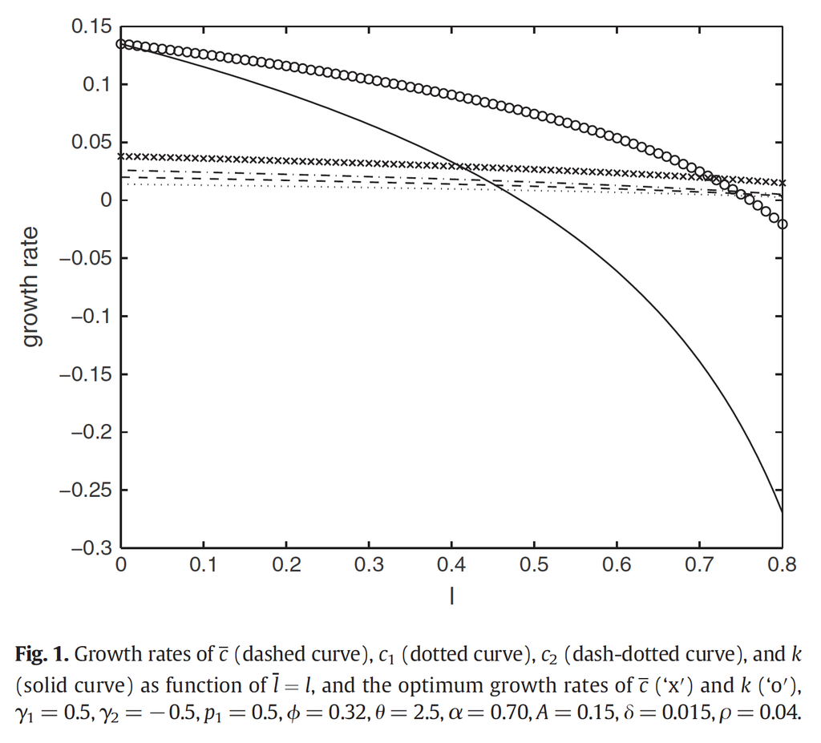

$\rightarrow$ The assumptions to reach overall degrowth do not seem realistic in the context of 2024 Western economies.

# 3 Carbon pricing

## 3.1 The model

This section is a summary of [Carbon Pricing versus Green Finance](https://papers.ssrn.com/sol3/papers.cfm?abstract_id=4382360), which compares two approaches to improve the environmental impact of corporations: **carbon pricing** (tax on GHG emissions) versus **green finance** (when investors have different expectations, i.e., impose different cost of capital on firms, especially polluting ones).

- If polluting is costly, the profit-maximization will impose a reduction of emissions;
- However, the transmission channel is less direct for the cost of capital.

$\rightarrow$ the paper concludes that if the **carbon price** is well calibrated, then green finance is superfluous and even counter-productive.  
$\rightarrow$ however, if the carbon tax is lower than the social cost, then green finance may help to improve welfare.

There are $N$ firms indexed by $i$ and the output function is
$$Y_i=a_i\epsilon_i^{s_i}L_i^{\beta_i}K_i^{\alpha_i},$$
where $K$ and $L$ are capital and labour, and $\epsilon=\text{ENERGY}/Y$ is an endogenous **energy intensity** (the production function can be re-written with ENERGY by changing exponents). $a>0$ is a productivity parameter, $s \in (0,1)$ and $\alpha+\beta < 1$.

Resorting to energy has two sources of costs:  
- its **price** $p_i=\lambda_i p_b+(1-\lambda_i)p_g$ is decomposed by the mix between green energy and brown energy. The total cost (expenditure) is thus $p_i \times \text{ENERGY}_i=p_i\epsilon_iY_i$.  
- potential **taxes** stemming from brown energy: $\tau_if_i\epsilon_iY_i$, where $\tau_i$ is the tax rate and $f_i$ is the intensity of the energy use (that converts energy into emissions, in tCO2/kWh).

The firm can reduce its carbon tax by buying offsets, $o_{i,q}$, where $q$ is the index of the *quality* of the offset - with exogenous price $\phi_q$. In the end, the firm’s profit is

$$\Pi_i=Y_i-wL_i-p_i\epsilon_iY_i-\tau_i \left(f_i\epsilon_iY_i-\sum_q o_{i,q} \right)^+-\sum_{q}o_{i,q}\phi_q$$
where $(x)^+=\max(x,0)$. The missing part, the capital $K_i$, comes from investment.

The net present value of the firm is

$$NPV_i=\frac{\Pi_i-(1-\delta)K_i}{1+r_i}-K_i=\frac{\Pi_i-(r_i+\delta)K_i}{(1+r_i)}, \tag{2}$$
where $r_i$ is the cost of capital (the expected profitability of the firm for owners) and $\delta$ is capital depreciation.

It is a 2-period model: at time 0, the firm chooses its capital/investment and at time $1$, the firm produces and pays the profit to the firm owners in such a way that maximizes its NPV. In other words, $L_i, \epsilon_i,\lambda_i,o_{i,q}$ are determined at time 1.

At time 0, the **representative household** is endowed with wealth $W$ and ownership of all firms. There is a riskless asset, with rate of return equal to $r>0$. Investing in firm $i$ is worth it only if the corresponding NPV is positive when taking $r$ as cost of capital in Equation 2. But $r_i$ can differ from $r$ if investors value extra financial criteria, such as GHG emissions for instance. At time 0, the household invests, and at time 1, it works, earns an endogenous wage $w$.

**Important**

**Consumption** equals all sources of income:
$$C=\underbrace{(1+r)\left(W-\sum_iI_i-I_b-I_g\right)}_{\text{savings}}+\underbrace{\sum_i\Pi_i+\Pi_b+\Pi_g}_{\text{profits}}+\underbrace{(1-\tau_x)w\sum_i L_i}_{\text{labour income}}+ K'+G,$$
indeed, in the model, two firms represent the green and brown energy section, indexed by $g$ and $b$, respectively. The last two terms are final capital and government spending (we refer to the original paper for their full expressions).

Finally, utility is consumption minus **negative utility** from working and emissions:
$$U=C-\bar{w}\sum_i L_i-T \left( \sum_{i}f_i\epsilon_iY_i-\sum_{i,q}qo_{i,q}-o_b-o_g \right)^+, \tag{3}$$

where $T$ is the social cost of carbon.

## 3.2 Equilibrium results

The carbon cost/price for a firms is the minimum between the tax or the cost to purchase offsets, i.e., it is $\tilde{\tau}_i=\min(\tau_i,\phi_{\bar{q}_i})$, with $\bar{q}_i$ being the lowest quality offset. Then, the total energy cost for firm $i$ is $\bar{p}_i=p_i+\tilde{\tau}_i f_i$ and in this case, the profit simplifies to:
$$\Pi_i=a_i\epsilon_i^{s_i}(1-\bar{p}_i\epsilon_i)L_i^{\beta_i}K_i^{\alpha_i}-wL_i$$
and the FOC yield the **optimal energy intensity**:
$$\epsilon_i^*=\frac{s_i}{1+s_i}\frac{1}{\bar{p}_i}$$
which is naturally decreasing in the total cost $\bar{p}_i$. Writing $A_i=\frac{a_i}{1+s_i}\left(\frac{s_i}{1+s_i} \frac{1}{\bar{p}_i} \right)^{s_i}$, the profit has then an even simpler form: $\Pi_i=A_iL_i^{\beta_i}K_i^{\alpha_i}-wL_i$ for which the optimal labour amount is
$$L^*_i=\left(\frac{\beta_iA_iK_i^{\alpha_i}}{w}\right)^{1/(1-\beta_i)},$$
and $w=\bar{w}/(1-\tau_w)$: optimal wage level is disutility of working divided by 1 minus income tax. The last important choice is with respect to **capital**. To do so, the latest expression of profit is
$$\Pi_i=A_i^{1/(1-\beta_i)}K_i^{\alpha_i/(1-\beta_i)}w^{-\beta_i/(1-\beta_i)}\beta_i^{\beta_i/({1-\beta_i})}(1-\beta_i),$$
and plugging this in the NPV in Equation 2 and the FOCs gives
$$K_i^*=\left((r_i+\delta)^{-1}A_i^{1/(1-\beta_i)}w^{-\beta_i/(1-\beta_i)}\beta_i^{\beta_i/(1-\beta_i)}\alpha_i \right)^{\frac{1-\beta_i}{1-\alpha_i-\beta_i}}$$

Note that the **social planner** seeks to maximize Equation 3. The full solution is slightly more complex than above due to idiosyncrasies for the green and brown sectors/firms. We refer to the proofs in the original paper.

## 3.3 Data…

Unfortunately the predictions from the model are mostly impossible to test, but it is useful to have a look at practices around the world. The author point to interesting data sources, especially the World Bank’s [carbon pricing dashboard](https://carbonpricingdashboard.worldbank.org/map_data), see also [ClimateWatch](https://www.climatewatchdata.org/).

# 4 Sustainable investing in equilibrium

This section is inspired by the paper [Sustainable investing in equilibrium](https://www.sciencedirect.com/science/article/abs/pii/S0304405X20303512).

## 4.1 Intuition

The core model is simple. There are $N$ firms with **excess returns** $\tilde{r}_n$, written in compact form $\tilde{\textbf{r}}=\boldsymbol{\mu}+\boldsymbol{\epsilon}$, with the latter being normally distributed with zero mean and covariance matrix $\boldsymbol{\Sigma}$.  
The firms also have an **observable** ESG characteristic,[^3] stacked into a vector $\textbf{g}$. The risk-free rate is $r_f$.

There is a continuum of agents, indexed with $i$, and with wealth dynamics
$$W_{t+1,i}=W_{t,i}(1+r_f+\textbf{x}_i'\textbf{r}).$$

Utility is over wealth and **ESG** component:

$$U_i=-e^{-A_iW_{t+1,i}-d_i\textbf{x}_i'\textbf{g}},$$

where $d_i$ measures the agent taste towards ESG. In the paper it is assumed positive, but in fact it could be negative (e.g.: “*anti-woke*” preferences). The utility-maximizing portfolio composition is:
$$\textbf{x}_i=\frac{1}{a_i}\boldsymbol{\Sigma}^{-1} \left(\boldsymbol{\mu}+\frac{d_i}{a_i}\textbf{g} \right),$$
with $a_i=A_iW_{t,i}$, but for simplicity, let us assume that all values are equal $a_i=a$. Then, we write $w_i$ for the share (relative wealth) of agent $i$. The market portfolio is
$$\textbf{w}_m=\int_i w_i\textbf{x}_idi=a^{-1}\boldsymbol{\Sigma}^{-1}\boldsymbol{\mu}+ \frac{\int_iw_id_idi}{a^2} \boldsymbol{\Sigma}^{-1} \textbf{g}.$$
Hence, plainly,
$$\boldsymbol{\mu}=a\boldsymbol{\Sigma}\textbf{w}_m-\frac{\bar{d}}{a}\textbf{g},$$
i.e., expected returns are negatively linearly related to ESG scores! If we multiply by $\textbf{w}_m$, we get the expression for the market excess return:
$$\mu_m=\textbf{w}_m'\boldsymbol{\mu}=a \sigma^2_m-\frac{\bar{d}}{a}g_m,$$
where $g_m$ is the ESG score of the market.

**Important**

If we assume that this ESG score is zero (e.g., data has been shifted and scaled), then the main result is that if we set $\boldsymbol{\beta}_m=\sigma_m^{-2}\boldsymbol{\Sigma}\textbf{w}_m$, we get:
$$\boldsymbol{\mu}=\mu_m\boldsymbol{\beta}_m-\frac{\bar{d}}{a}\textbf{g}, \tag{4}$$
i.e., return = market + sustainability components.

The first component is shared (market beta) and the second one adjusts it.

## 4.2 Empirical exercise

We load a database from an online source (the introductory course on green finance).  
We refer to this particular [section](https://www.greenfinance.education/data.html#exploring-a-dataset-on-us-corporations) for more details on its content.  
Note that below, we are working with **realized returns** and not **expected returns**.

```r
url <- "https://github.com/shokru/greenfinance.github.io/raw/main/ESG_data.RData?raw=true"
load(url(url))
head(ESG_data, 4)
```

| Source | Tick | CUSIP | ISIN | Name | Date | Close | Market_Cap | ESG_Metric | E_Score | S_Score | G_Score | Scope_1 | Scope_2 | Scope_3 | Sector |
| --- | --- | --- | --- | --- | --- | --- | --- | --- | --- | --- | --- | --- | --- | --- | --- |
| Provider_A | AAL | 02376R102 | US02376R1023 | AMERICN ARLNS | 2005-12-31 | NA | NA | NA | NA | NA | NA | NA | NA | NA | Other |
| Provider_A | AAL | 02376R102 | US02376R1023 | AMERICN ARLNS | 2006-01-31 | NA | NA | NA | NA | NA | NA | 31200 | 400 | NA | Other |
| Provider_A | AAL | 02376R102 | US02376R1023 | AMERICN ARLNS | 2006-02-28 | NA | NA | NA | NA | NA | NA | 31200 | 400 | NA | Other |
| Provider_A | AAL | 02376R102 | US02376R1023 | AMERICN ARLNS | 2006-03-31 | NA | NA | NA | NA | NA | NA | 31200 | 400 | NA | Other |

```r
ESG_data <- ESG_data |> arrange(Source, Date)
```

There are two data providers, but their ESG scores measure different things and have opposite meaning.

First, let’s compute and add returns.

```r
ESG_data <- ESG_data |>
  mutate(return = Close/lag(Close)-1, .by = Tick) |>
  filter(is.finite(return))
```

Then, group firms and average their returns within groups. This procedure of sorting and computing average returns is very standard.  
**NOTE**: returns are monthly for Provider A and annual for Provider B.

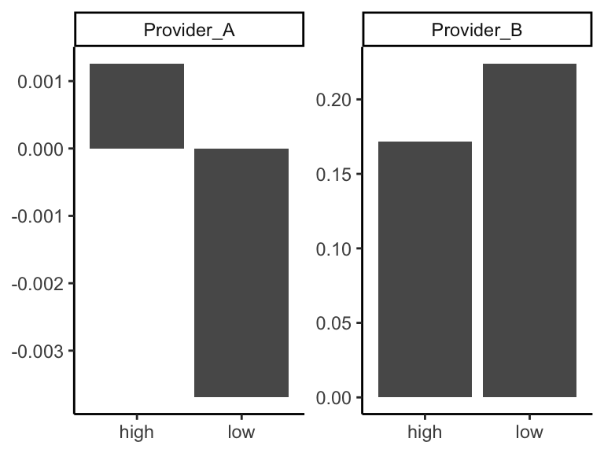

```r
ESG_data |>
  mutate(type = if_else(ESG_Metric > median(ESG_Metric, na.rm = T),
                        "high", "low"), .by = c(Source, Date)) |>
  filter(!is.na(type)) |>
  summarise(avg_ret = mean(return, na.rm = T), .by = c(Source, type)) |>
  ggplot(aes(x = type, y = avg_ret)) + facet_wrap(vars(Source), scales = "free") +
  geom_col() + theme_classic() +
  theme(axis.title = element_blank())
```

The story is not the same depending on the data provider…  
Now, let’s have a look at the link from Equation 4.  
The market return is common to all stocks, hence treated as a constant.

```r
ESG_data |>
  mutate(return = Close/lag(Close)-1, .by = Tick) |>
  group_by(Tick, Source) |>
  summarise(ret = mean(return, na.rm = T),
            esg = mean(ESG_Metric, na.rm = T)) |>
  group_by(Source) |>
  group_modify(.f = ~ broom::tidy(glm(ret ~ esg, data = .x))) |>
  mutate(across(is.numeric, round, digits = 3))
```

| Source | term | estimate | std.error | statistic | p.value |
| --- | --- | --- | --- | --- | --- |
| Provider_A | (Intercept) | 0.012 | 0.001 | 11.213 | 0.000 |
| Provider_A | esg | 0.000 | 0.000 | -0.460 | 0.645 |
| Provider_B | (Intercept) | 0.242 | 0.022 | 10.949 | 0.000 |
| Provider_B | esg | -0.002 | 0.000 | -4.818 | 0.000 |

The fact that the sign for ESG *t*-stat is the same is not good, as both metric have opposite interpretation (one is a score, the other is a risk measure)…

$\rightarrow$ ESG divergence, disagreement, confusion, etc.

## Footnotes

[^1]: In the AER, searching for the term “*climate*” early 2024 yields ~45 results with a first publication in 2006.
[^2]: And also $\bar{\gamma}=\sum_j p_j\gamma_j \neq \theta/(1-\theta)$.
[^3]: This is subject to debate, as there are [**many**](https://academic.oup.com/rof/article/26/6/1315/6590670) ways to evaluate sustainability.